# Exam Business Analytics

Antonella Facini

2024-05-02

## **About the Exam**

It will take 1.5 h Open Book

Theory: written part with theory and output interpretation (16 points) Practice: on R, report on some analysis (18 points)

## **Structure**

1. Time Series
2. Quantile Regression
3. Simulation and Monte Carlo Analysis

## **Forecasting and time series (1)**

```r
library(ggplot2, quietly = T)
library(dplyr, quietly = T)
```

The ability to forecast depends on:

- how well we understand the factors that contribute to it;
- how much data is available;
- how similar the future is to the past;
- variability of the process of interest;
- whether the forecasts can affect the thing we are trying to forecast.

Some processes occur on a temporal scale (sales, temperature, stock prices, number of new graduates in a country, etc) .

Even for processes that occur at continuous time scale, observations can only take place at discrete time steps. Data is often collected at regular time-step. Time is a defining property of the data.

For example, the evolution of atmospheric carbon dioxide dry air mole fractions; monthly medicare Australia prescription data for antidiabetic drugs; turnover for takeaway food services; Google stock prices at closing time;

### Forecasting from a statistical perspective

Thing to be forecast: a random variable $y_t$; The distribution of the forecast: If $I$ is all observations, then $y_t|I$ means “the random variable $y_t$ given what we know in $I$”. The point forecast is the mean (or median) of$y_t|I$ The forecast variance is $var_[y_t | I]$

A prediction interval or interval forecast is a range of values of $y_t$ with high probability.

With time series, $y_(t|t−1) = y_t |{y1, y2, . . . , yt−1}$.

$\hat{y}_(T+h|T) = E[y_T+h|y1, . . . , y_T ]$ (an h-step forecast taking account of all observations up to time T).

### Time Series and Patterns

**Trend** : pattern exists when there is a long-term increase or decrease in the data.

**Seasonality**: pattern exists when a series is influenced by seasonal factors (e.g., the quarter of the year, the month, or day of the week).

**Cyclic**: pattern exists when data exhibit rises and falls that are not of fixed period (duration usually of at least 2 years).

**Seasonality v Cyclic**: Seasonality usually has a constant/less variable magnitude v. Cycle magnitude is more variable;

Seasonal pattern has constant length v. Cyclic pattern has variable length;

Average length of cycle pattern is longer v. Average length of seasonal pattern is shorter

Timing of peaks is circa predictable on the long term for seasonal data v. Timing is unpredictable on the long term for cyclic data

Short term it is easier to predict potential peaks in cyclic data rather that in seasonal data

### Autocorrelation and Lag Plot

Keep in mind that the purpose is to perform a **regression**

An important underlying assumption for the regression is **Variables independence**

**In reality does this assumption hold?** No! Think of a time series of ice-cream sales. All sales in August months are not independent one to each other. Sales, temperatures and stock-prices of today sometimes are influenced by yesterday values.

**Autocorrelation is the first tool used to detect either seasonality or cyclicality**

We will compare a value at time $t$ with respect to a value at time $t - k$ for different values of $k$, computing the correlation among the value and the lagged one.

#### Lag Plot

A lag plot is a special type of scatter plot with the two variables (X,Y) “lagged.” A “lag” is a fixed amount of passing time (K); One set of observations in a time series is plotted (lagged) against a second, later set of data.

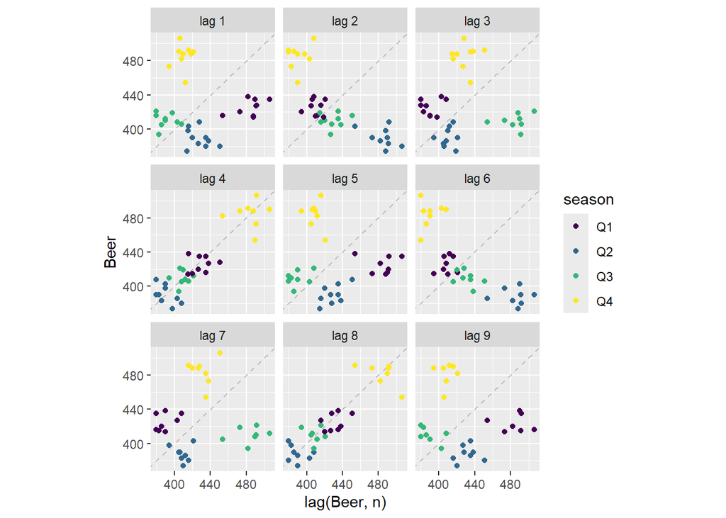

```r
library(fpp3)
aus_production%>%
  filter(year(Quarter)>2000)%>%
  gg_lag(Beer, geom = 'point')
```

I notice seasonality:

- **Quarters Clustering together**: if there’s seasonality in the data, you’d expect to see patterns emerge where data points from the same quarter tend to be closer to each other. It means that the data points corresponding to the same quarter across different years tend to form distinct clusters or groups. This clustering indicates that there’s a recurring pattern or seasonality within each quarter of the year.
- **Potential Annual Seasonality**: At lag 4,there is a more specific pattern where not only the quarters cluster together, but there’s also a linear pattern within each quarter across different years. This finding suggests an annual seasonality, meaning that there’s a repeating pattern in beer production on a yearly basis.

#### Autocovariance and autocorrelation

**Autocovariance and autocorrelation**: measure linear relationship between lagged values of a time series y.

**Note: when variables are independent then the correlation is null**

Sample autocovariance at lag $k$ is $c_k$

Sample autocorrelation at lag $k$ is $r_k$

Where:

$c_k = \frac{1}{T}\sum_{t=k+1}^{T} (y_t - \bar{y})(y_{t-k} - \bar{y})$

$r_k = c_k / c_0$

**The autocorrelation at lags 1,2,.. make up the autocorrelation function or ACF**

*Australian Beer Production*

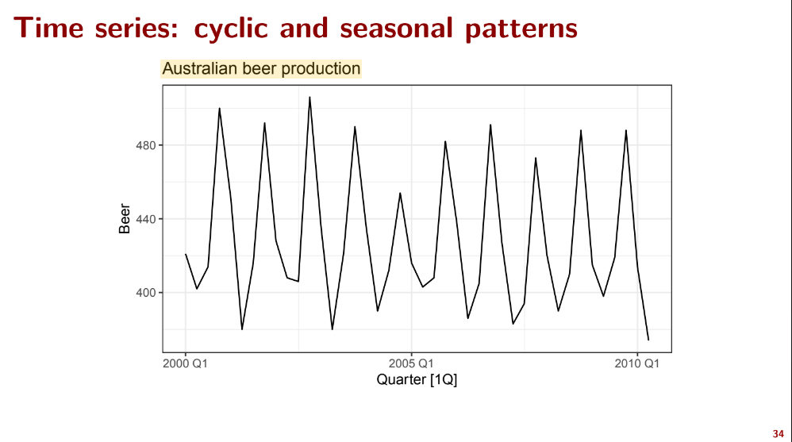

Australian Beer Production, Time Series

```
## Response variable not specified, automatically selected `var = Beer`
```

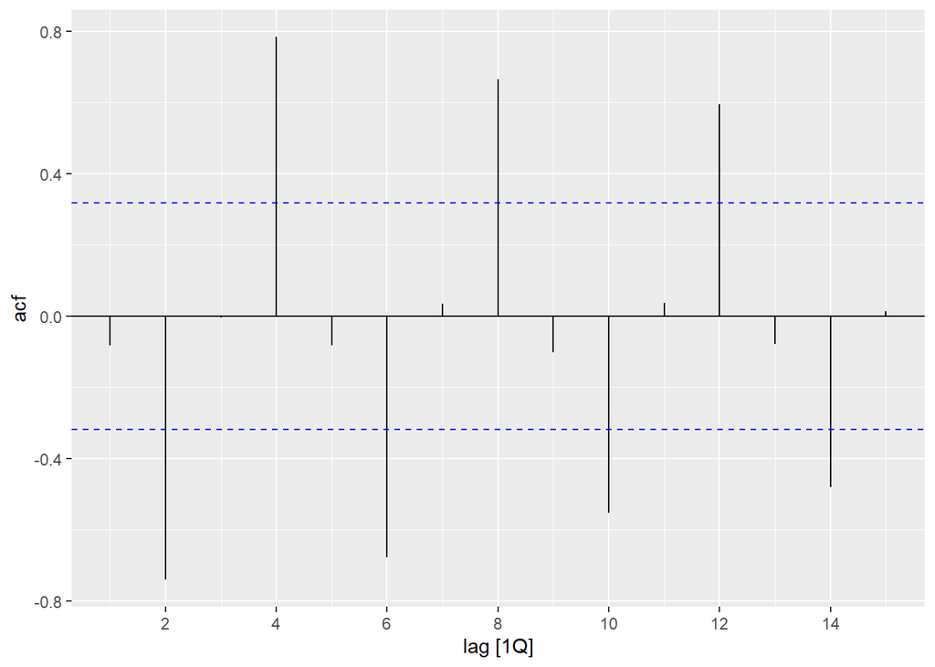

```r
aus_production%>%
  filter(year(Quarter)>2000)%>%
  ACF()%>%
  autoplot()
```

**Annual seasonality confirmed, for each year the variables are strongly linearly correlated**.

Specifically,

*Positive Autocorrelation at Lag 4, 8, 12, …:* there’s a recurring pattern where beer production tends to follow a similar trend each year

*Negative Autocorrelation at Lag 2, 6, 10, 14, …:* it reflects a “reversal” or “alternating” pattern in the data. At these lags, we’re looking at pairs of quarters with specific time intervals between them: 6 months (lag 2), 1 year and 6 months (lag 6), 2 years and 6 months (lag 10), and so forth.

The negative autocorrelation at these lags suggests a pattern where the quarters separated by these intervals exhibit an “inverse” relationship in terms of beer production.

For example, if there’s a peak in beer production during a particular quarter, the corresponding quarter at the specified lag will tend to have a decrease in production, and vice versa. This inverse relationship can be due to various factors such as seasonal shifts, supply chain dynamics, or consumer behavior patterns.

These negative autocorrelations at specific lags indicate a more complex temporal pattern beyond simple yearly seasonality, suggesting additional cyclical or alternating trends in the data.

*Retail Employment in the USA*

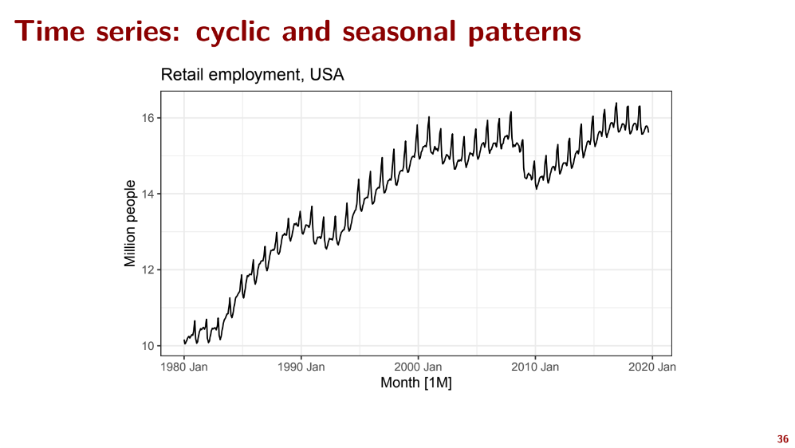

Retail Employment, USA, Time Series

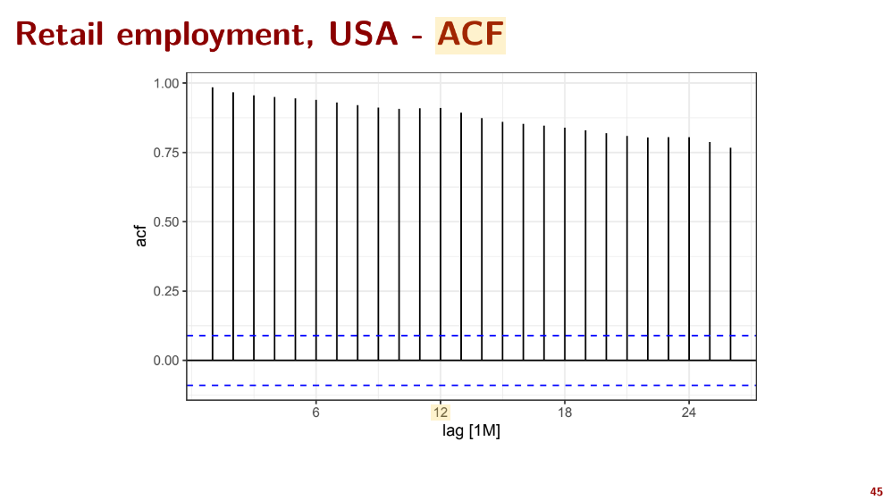

Retail Employment, USA, ACF

By looking to the time series, it is evident an increasing trend, a cyclical pattern and also a seasonal pattern.

By looking at the ACF the strength of the increasing trend is confirmed:

**Decreasing Autocorrelation with Increasing Lags**: In a time series with a strong increasing trend, each observation tends to be larger than the previous one. As a result, observations farther apart in time are likely to be less correlated with each other

**Slower Decay in Autocorrelation**: the decay in autocorrelation might be slower compared to a stationary time series. This slower decay occurs because the increasing trend introduces a systematic relationship between observations that persists over longer time periods.

**BOTTOMLINE: When data have a trend (meaning it either increases or decreases), the autocorrelations for small lags tend to be large and positive (following the same path); When data are seasonal, the autocorrelations will be larger at the seasonal lags (i.e., at multiples of the seasonal frequency); When data are trended and seasonal, you see a combination of these effects; Time series that show no autocorrelation are called white noise.**

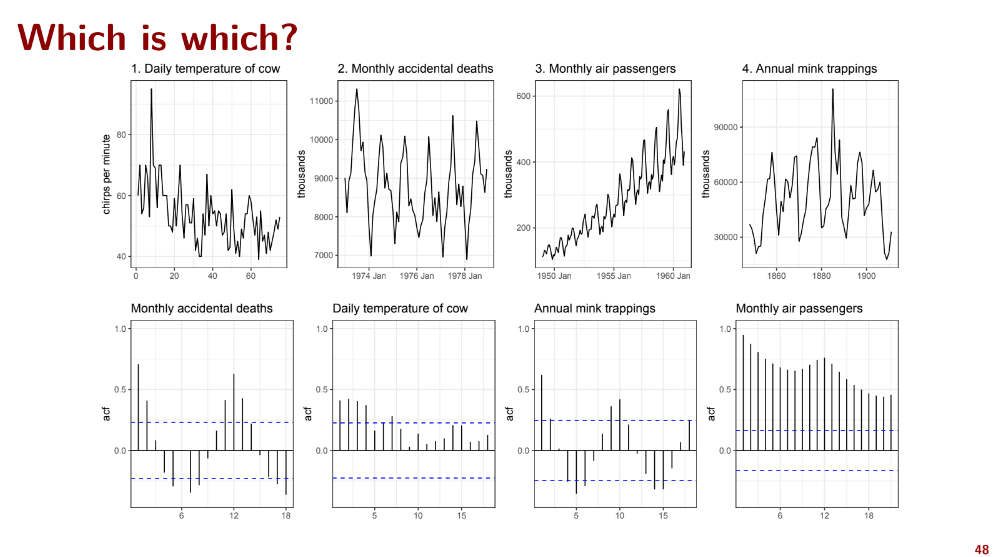

### Transformations

Avoid comparing apples with oranges.

Think of comparison between absolute GDP of two countries. It is not meaningfull. The value is influenced by the population. An adequate transformation would be ‘by population’.

- Population adjustments (GDP of USA in 1960 and 2023), Calendar adjustments (total monthly sales,total yearly sale in leap years), Inflation adjustments
- Mathematical adjustments: to stabilize the variance

#### Transformations: Log-Transformation

Sometimes the variability of the series changes with its level, think of a time series with an increase in magnitude of the seasonal term.

Log’s advantage: *interpretability*

When we take the logarithm of a variable, we’re essentially transforming the scale of the data.

When you take the logarithm of a variable and observe changes over time, what you’re essentially seeing are relative changes rather than absolute changes.

Logarithmic transformation compresses large values more than small values.

### Decomposition

Time series are characterized by: *Trend-cycle component (*$T_t$), a *Seasonal component (*$S_t$), and a *Remainder Unexplained Component (*$R_t$)

Data at a period t ($y_t$) can be then described as

$$y_t= f(S_t,T_t,R_t)$$

Composition of Seasonality can be either **Additive** or **Multiplicative**

**Additive model**:appropriate if magnitude of seasonal fluctuations does not vary with level.

**Multiplicative model**: appropriate if seasonal changes are proportional to level of series; they can be transformed into an additive model through log-adjustment.

$$y_t=log(S_t) - log(T_t) +
log(R_t)$$
**Classical decomposition** can be performed for additive and multiplicative seasonality.

### Moving Averages

**Purpose: to smooth out the seasonal component. It will be used a moving average of order m established by the periodicity of the time series.**

Moving averages by definition are symmetric and centered at time t, and imply the need of an **odd** $m$.

When dealing with **even** $m$ take a moving average of the moving averages.Therefore compute a **Weighted Moving Average**. For seasonal data with even period m **take 2 × MA of period m (2 x m-MA)**.

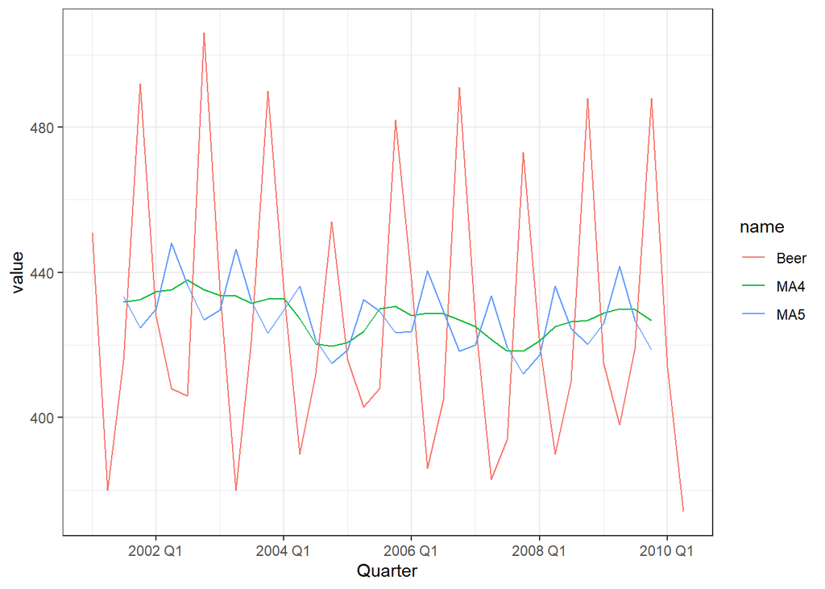

```r
#i must make a weighted average, giving weights, specifically lower weights for outsiders
#MA4-> 5 observations taken, since mathematically you compute the moving average for two different sets;
#the weights are mathematically computed.

library(slider)

MAs<-aus_production%>%
  filter(year(Quarter)>2000)%>%
  select(Quarter,Beer)%>%
  mutate(MA5=slider::slide_dbl(Beer, .f = mean, .before = 2, .after = 2, .complete = TRUE),
         MA4=slider::slide_dbl(Beer, .f = weighted.mean, .before = 2, .after = 2,w=c(1/8,1/4,1/4,1/4,1/8), .complete = TRUE))

ggplot(MAs%>% pivot_longer(cols = -Quarter))+
  geom_line(aes(Quarter, value, col=name))+
  theme_bw()
```

The greater m, the less observations we keep. The smaller m, the more observations we keep.

Note: the choice of m affects drastically strongly seasonal data. Obviously it reduces the seasonality component, the greater $m$.

### Classical Decomposition

We use the function ‘classical decomposition’. It derives the trend component, seasonal component, random component and also the adjusted values for seasonality.

We first break down how to compute manually the seasonal term.

The trend component is derived as MA.

The seasonal component, in the model is computed as the seasonal mean of detrended data

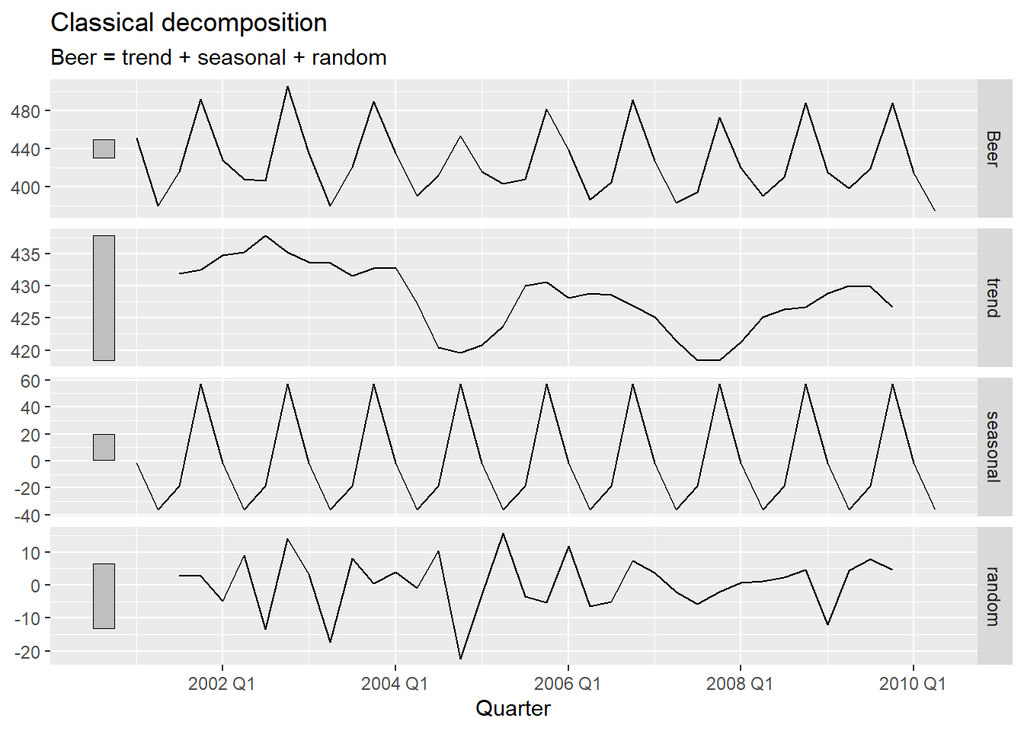

```r
#additive model
ausdecomp <-
  aus_production %>% filter(year(Quarter) >2000) %>%
    select(Quarter, Beer) %>%
  model(classical_decomposition(Beer)) %>%
  components()

#model's plot
ausdecomp %>% autoplot()
```

```r
#seasonal term computation: derived from seasonal means: quanta varianza c'è in ogni stagione?
seasMeans <- ausdecomp %>%
  mutate(q = quarter(Quarter),
         # value - trend
         detrended = Beer - trend) %>%
  as_tibble() %>% group_by(q) %>%
  summarise(seasonal = mean(detrended, na.rm = TRUE)) %>%
  pull(seasonal)

#just enforced to have 0 mean
seasMeans-mean(seasMeans)
```

```
## [1]  -1.829427 -36.313802 -18.615885  56.759115
```

```r
#actual comparison to the original model
ausdecomp %>% slice(1:4) %>% pull(seasonal)
```

```
## [1]  -1.829427 -36.313802 -18.615885  56.759115
```

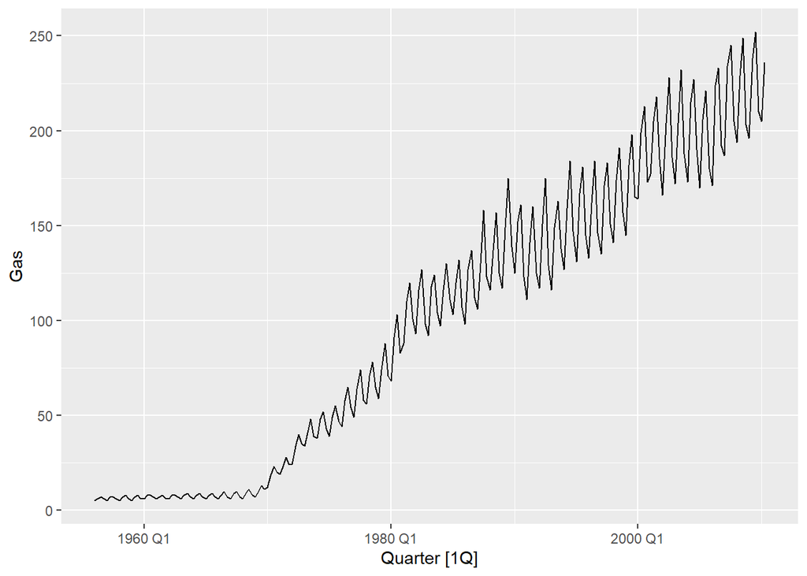

```r
#multiplicative model: seasonality increasing in magnitude
aus_production %>%
  autoplot(Gas)
```

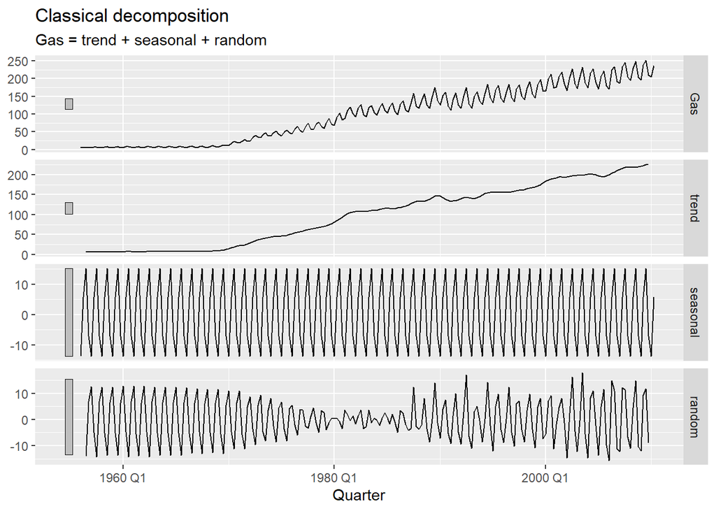

```r
#additive does not detect seasonality properly, look at the random component plot
AddGasDecomp<- aus_production%>%
  model(ngas_decomp=classical_decomposition(Gas, type='a'))%>%
  components()

#option 1: multiplicative
MultGasDecomp <- aus_production %>%
  model(gas_decomp= classical_decomposition(Gas, type = "m")) %>%
  components()

#option 2: log-transformation, additive
AddLGasDecomp <-  aus_production %>%
  model(lgas_decomp= classical_decomposition(log(Gas), type = "a")) %>%
  components()

AddGasDecomp%>%autoplot()
```

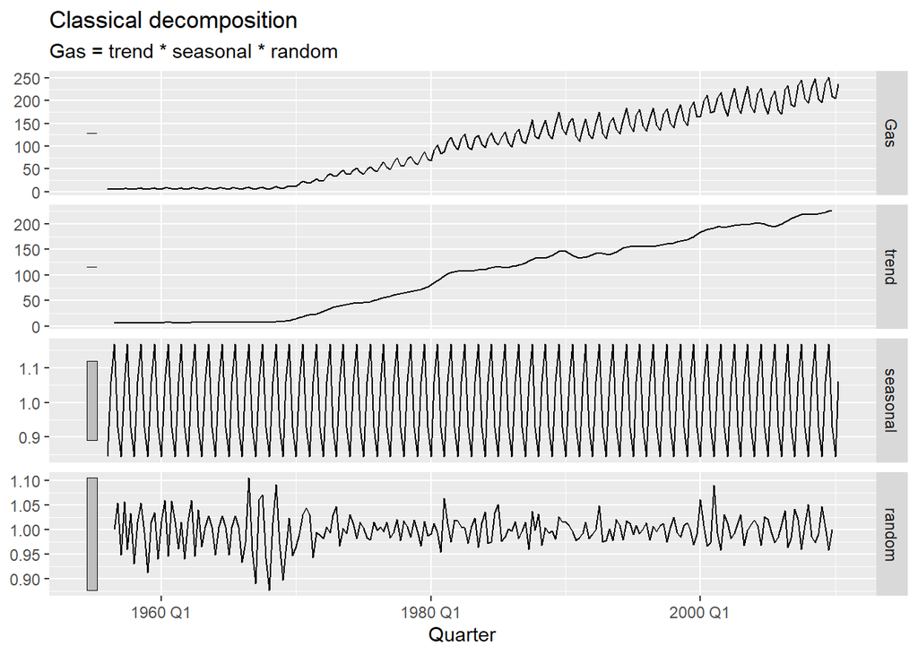

```r
MultGasDecomp %>% autoplot()
```

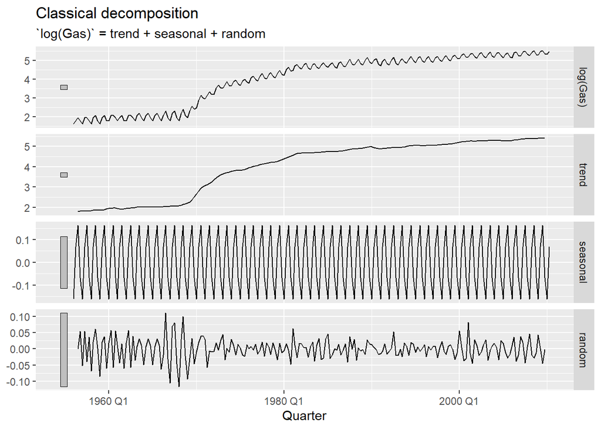

```r
AddLGasDecomp %>% autoplot()
```

**Classical decomposition drawbacks**: - The estimate of the *trend-cycle* (also the remainder) is unavailable for the first and last observations

- The estimate of the *trend-cycle* tends to over-smooth rapid rises and falls (MA)
- Assumption of constant seasonal terms might be too conservative
- The estimate is not robust, very sensitive to large variations in small number of points

### Exponenatial Smoothing: forecasting

Main idea: forecasts are based on weighted averages of past observations.

The weights are heavier for the more recent past.

The decay of the weights is exponential.

2 Cases: Data without trend/seasonal term; Data with trend/seasonal term

#### Simple Exponential Smoothing (SES)

**No trend; No seasonality**

1. Data at time $h$ are equal to the last observed value of the series.

$$\hat{y}_{T+h|T} = y_T$$

- the most recent observation is the only important one
- previous observations provide no info
- weighted average in which all the weight is given to the last observation
2. Data at time $h$ are equal to the simple average of all observed data.

$$\hat{y}_{T+h |T}=
\frac{1}{T}\sum_{t=1}^{T}y_t$$

- all observations are of equal importance
- weighted average in which all observations have same weight
3. SES: forecasted data are calculated using weighted averages, where the weights decrease exponentially as the observations come from further in the past;

$$\hat{y}_{T+1 | T}= \alpha y_T + \alpha
(1 - \alpha)y_{T-1}+\alpha (1-\alpha^2)y_{T-2}...$$

- where $0<\alpha<1$
- $T+1$ forecast is a weighted average of all of the observations in the series;
- The bigger alpha, the more importance is given to recent observations; The bigger alpha, the closer the forecasts to the real observations;
- The smaller alpha, the more importance is given to observations from the more distant past; more importance to the overall mean; The smaller alpha, the closer the forecasts to the mean of observations;

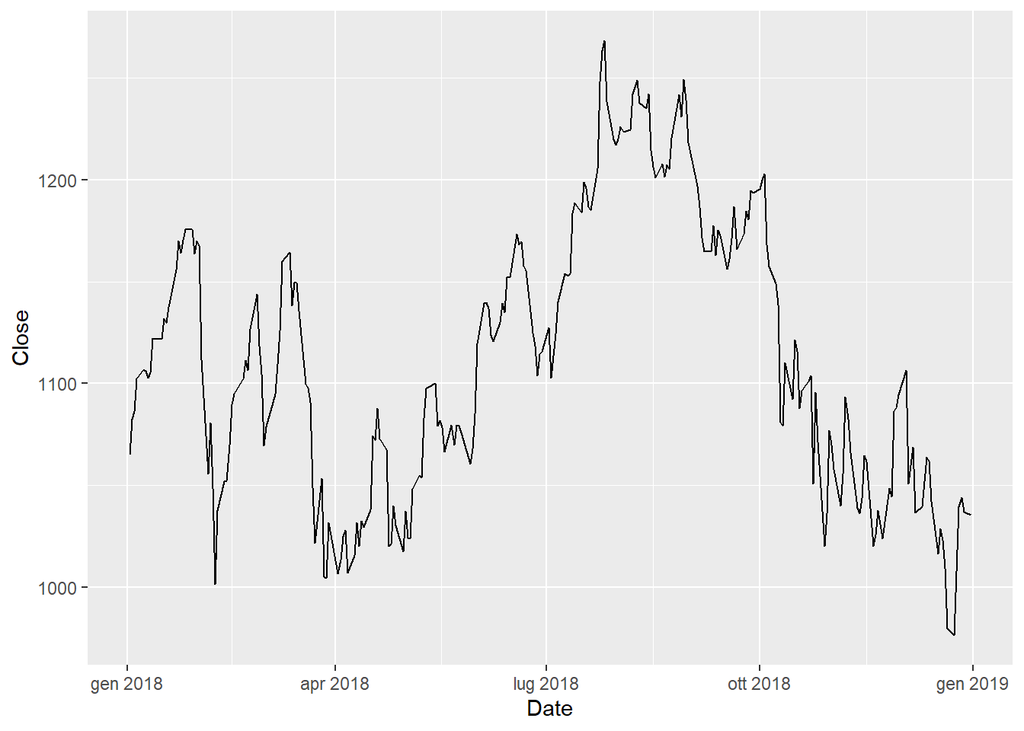

```r
#TRY: plot the data just as it is; missing weekend values = steps in the graph
gafa_stock%>%
  filter(Symbol=='GOOG',year(Date)>=2018)%>%
  ggplot(aes(x=Date,y=Close))+
  geom_line()
```

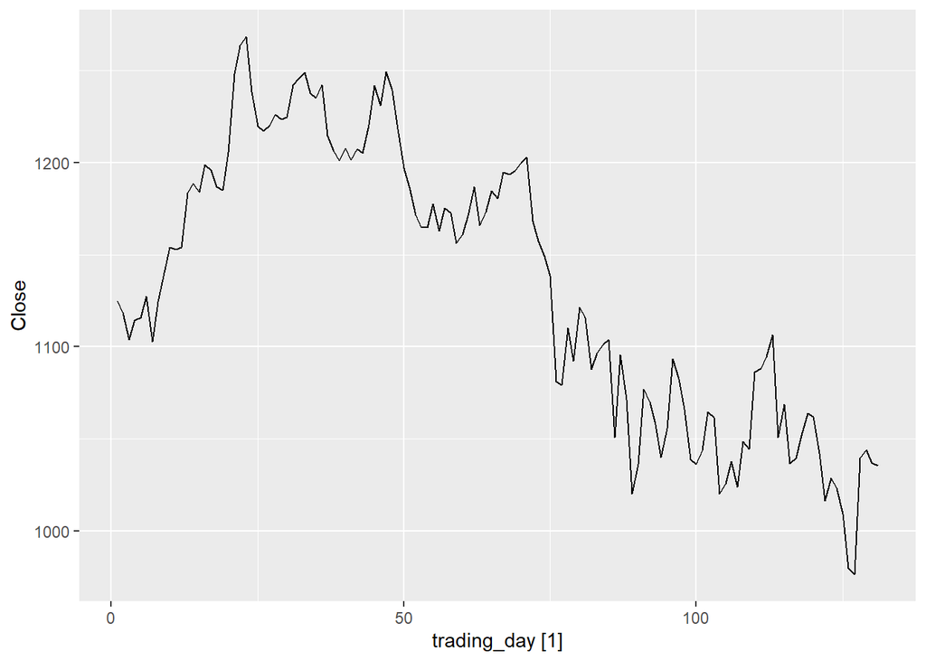

```r
#DATA PREPARATION; financial series: we must look at the trading day
goog <- gafa_stock %>%
  filter(Symbol == "GOOG", year(Date) >= 2018) %>%
  mutate(trading_day = row_number()) %>%
  update_tsibble(index = trading_day, regular = TRUE)
goog_sub <- goog %>% filter(trading_day > 120) %>%
  select(trading_day, Close) %>%
  mutate(trading_day = trading_day-120)
goog_sub %>% autoplot(Close)
```

```r
#Fit SES model
fit<-goog_sub%>%
  model(SES=ETS(Close ~ trend('N')+ season('N')))

fit%>%glance()
```

```
## # A tibble: 1 × 9
##   .model sigma2 log_lik   AIC  AICc   BIC   MSE  AMSE   MAE
##   <chr>   <dbl>   <dbl> <dbl> <dbl> <dbl> <dbl> <dbl> <dbl>
## 1 SES      390.   -709. 1424. 1424. 1433.  384.  700.  14.5
```

```r
#Visualize estimates: optimal alpha and l_0
fit%>%tidy
```

```
## # A tibble: 2 × 3
##   .model term  estimate
##   <chr>  <chr>    <dbl>
## 1 SES    alpha    0.939
## 2 SES    l[0]  1124.
```

```r
#Visualize the component form: Observation, Level, Remainder
fit%>%components()
```

```
## # A dable: 132 x 5 [1]
## # Key:     .model [1]
## # :        Close = lag(level, 1) + remainder
##    .model trading_day Close level remainder
##    <chr>        <dbl> <dbl> <dbl>     <dbl>
##  1 SES              0   NA  1124.    NA
##  2 SES              1 1125. 1125.     0.442
##  3 SES              2 1118. 1119.    -6.32
##  4 SES              3 1104. 1105.   -14.9
##  5 SES              4 1114. 1114.     9.34
##  6 SES              5 1116. 1116.     2.00
##  7 SES              6 1127. 1127.    11.9
##  8 SES              7 1103. 1104.   -23.8
##  9 SES              8 1124. 1123.    19.9
## 10 SES              9 1140. 1139.    17.1
## # ℹ 122 more rows
```

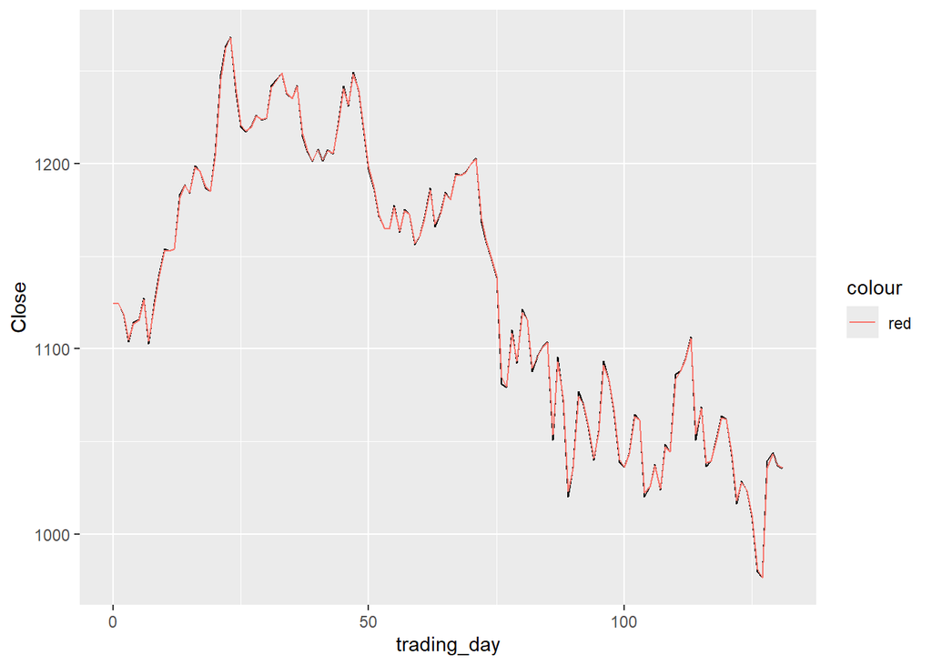

```r
#Plot the Original Time Series v Level Values
#NOTE. YOU ARE NOT FORECASTING ANY VALUES

fit%>%
  components()%>%
  ggplot()+
  geom_line(aes(x=trading_day, y=Close))+
  geom_line(aes(x=trading_day,y=level, col='red'))
```

```r
#compare different alphas: optimal v. small v. smaller
fit<-goog_sub%>%
  model(SES=ETS(Close~trend('N')+season('N')),
        SESa003=ETS(Close~trend('N', alpha=0.03)+season('N')),
        SESa007=ETS(Close~trend('N', alpha=0.07)+season('N')))

#components() gives observation and level, you would have to compute the fitted
#augment() creates dataframe, adds column .fitted, ideal for plots
fit%>%augment()
```

```
## # A tsibble: 393 x 6 [1]
## # Key:       .model [3]
##    .model trading_day Close .fitted  .resid  .innov
##    <chr>        <dbl> <dbl>   <dbl>   <dbl>   <dbl>
##  1 SES              1 1125.   1124.   0.442   0.442
##  2 SES              2 1118.   1125.  -6.32   -6.32
##  3 SES              3 1104.   1119. -14.9   -14.9
##  4 SES              4 1114.   1105.   9.34    9.34
##  5 SES              5 1116.   1114.   2.00    2.00
##  6 SES              6 1127.   1116.  11.9    11.9
##  7 SES              7 1103.   1127. -23.8   -23.8
##  8 SES              8 1124.   1104.  19.9    19.9
##  9 SES              9 1140.   1123.  17.1    17.1
## 10 SES             10 1154.   1139.  14.9    14.9
## # ℹ 383 more rows
```

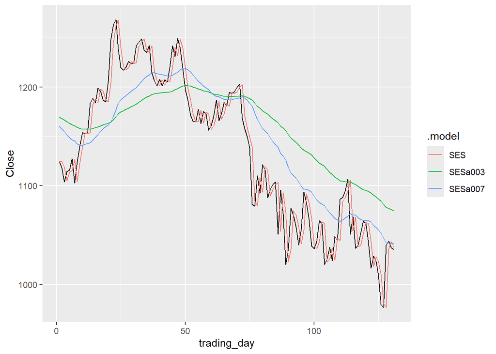

```r
#plot observations v. fitted values of the three models
fit%>%
  augment()%>%
  ggplot()+
  geom_line(aes(trading_day,Close))+
  geom_line(aes(trading_day,.fitted, col=.model))
```

**FORECASTING**

```r
#FORECASTING
fit%>%
  forecast(h=5)
```

```
## # A fable: 15 x 4 [1]
## # Key:     .model [3]
##    .model  trading_day         Close .mean
##    <chr>         <dbl>        <dist> <dbl>
##  1 SES             132  N(1036, 390) 1036.
##  2 SES             133  N(1036, 735) 1036.
##  3 SES             134 N(1036, 1079) 1036.
##  4 SES             135 N(1036, 1424) 1036.
##  5 SES             136 N(1036, 1768) 1036.
##  6 SESa003         132 N(1073, 3198) 1073.
##  7 SESa003         133 N(1073, 3201) 1073.
##  8 SESa003         134 N(1073, 3204) 1073.
##  9 SESa003         135 N(1073, 3207) 1073.
## 10 SESa003         136 N(1073, 3210) 1073.
## 11 SESa007         132 N(1041, 1642) 1041.
## 12 SESa007         133 N(1041, 1650) 1041.
## 13 SESa007         134 N(1041, 1658) 1041.
## 14 SESa007         135 N(1041, 1666) 1041.
## 15 SESa007         136 N(1041, 1674) 1041.
```

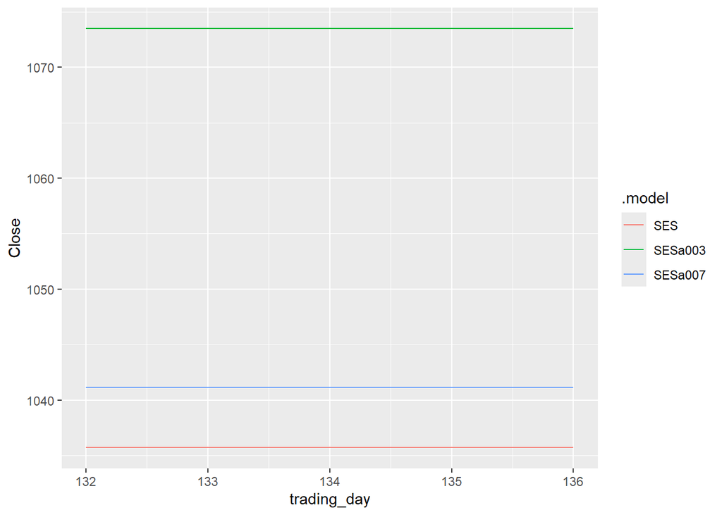

```r
#PLOT FORECASTED VALUES (NOTE:CANNOT PLOT DF, NO AUGMENTED)
fit%>%
  forecast(h=5)%>%
  autoplot(level=NULL)
```

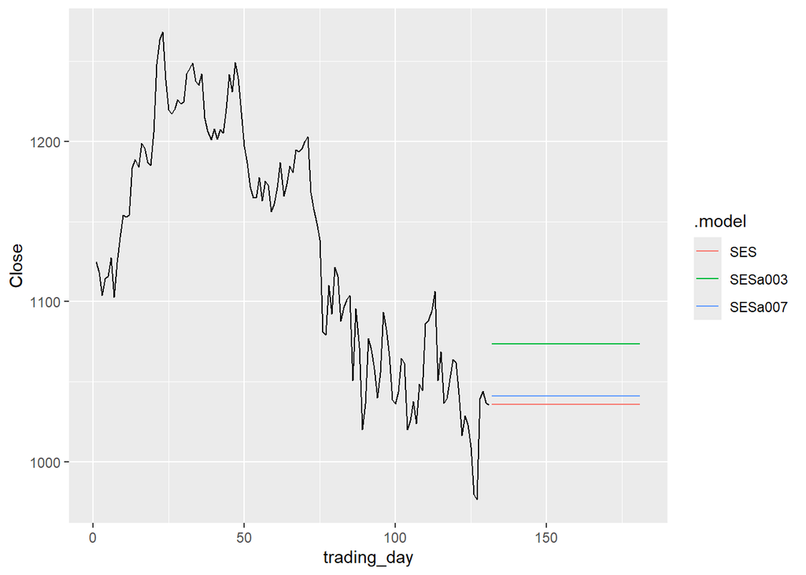

```r
#PLOT FORECASTED VALUES V. ORIGINAL TS
fit%>%
  forecast(h=50)%>%
  autoplot(goog_sub, level= NULL)
```

**Exponential Weighted Moving Average:**

- it is the graph obtained from the SES model applied to all real observations;
- starting point defined by $l_0$;
- iterate the following formula until time $T$

At $t=1$, $\hat{y}_{1|0}= l_0$

At $t=2$, $\hat{y}_{2|1}= l_1 = \alpha y_1 + (1-\alpha) l_0$

At $t=3$, $\hat{y}_{3|2}= l_2 = \alpha y_2 + (1-\alpha) l_1$

…

At $t=T+1$
$$\hat{y}_{T+1|T}= l_T = \alpha y_T +
(1-\alpha)l_{T-1} = \sum_{j=0}^{T-1} \alpha (1-\alpha)^j y_{T-j} +
(1-\alpha)^T l_0$$

**The component form of SES**

is given by:

*Forecast Equation*
$$\hat{y}_{t+h|t}= l_t$$

*Smoothing Equation*
$$l_t= \alpha
y_t + (1-\alpha)l_{t-1}$$

- where $l_t$ is the level or smoothed value of the time series at time $t$
- by setting $h=1$ we get the fitted values of the time series
- by setting $t=T$ we get the true forecasts beyond the training data

**Flat Forecasts**

All forecasts (no matter $h$) take the same value, equal to the last level component. This is why it is only suitable if the time series has no trend or seasonal component.

$$\hat{y}_{t+h|t}= l_t$$
for $h=1,2,3..$

**Parameters choice** : $\alpha$ and $l_0$ are estimated following the minimizing SSE rule (just as in any regression)

#### Exponential Smoothing with Trend Component: Double Exp Sm or Holt’s Method

**Trend description:**

- consider the first obs and the last, then this would be the global description of the trend (either increasing or decreasing);
- we could consider a local trend, so the change in $y_t$ and $y_t+1$. Locally, we can have both increases and decreases;
- we will use a middle approach

**The average change is** : $\frac{1}{T}(y_T - y_1)$

**The component form of ES with Trend**

*Forecasting Equation*: $\hat{y}_{t+h|t}= l_t + h \cdot b_t$

*Level Equation*: $l_t =\alpha y_t + (1-\alpha)(l_{t-1}+b_{t-1})$

*Trend Equation*: \(b_t= $\beta^*$(l_t - l_{t-1})+(1-$\beta^*$)b_{t-1}\)

- $l_t$ is an estimate of the level of the series at time $t$; $b_t$ is an estimate of the trend (slope) of the series at time $t$
- $\alpha$ is the smoothing parameter for the level;$\beta^*$ is the smoothing parameter for the trend
- *Level equation* is a weighted average of observation $y_t$ and the one step-ahead training forecast for time $t$ given by $l_{t-1}+b_{t-1} =\hat{y}_{t|t-1}$
- *Trend equation* shows that $b_t$ is a weighted average of the estimated trend at time $t$ based on $(l_t - l_{t-1})$ and $b_{t-1}$, the previous estimate of the trend
- The forecast will not be flat, instead it will be trending
- The h-step-ahead forecast is equal to the last estimated level plus h times the last estimated trend value. Hence the forecasts are a linear function of h.

**Parameters choice**: optimal (, $\beta^*$, l_0, b_0) minimising SSE

```r
#fit model: SES (flat forecast); DES (sloped forecast); dDES (dumped forecast;)
fit2<-goog_sub%>%
  model(SES=ETS(Close ~ trend('N')+ season('N')),
        DES=ETS(Close~ trend('A')+ season('N')),
        dDES=ETS(Close~ trend('Ad')+ season('N')))

#visualize observation, l_t, b_t and remainder
fit2%>%components()
```

```
## # A dable: 396 x 6 [1]
## # Key:     .model [3]
## # :        Close = lag(level, 1) + lag(slope, 1) + remainder
##    .model trading_day Close level remainder slope
##    <chr>        <dbl> <dbl> <dbl>     <dbl> <dbl>
##  1 SES              0   NA  1124.    NA        NA
##  2 SES              1 1125. 1125.     0.442    NA
##  3 SES              2 1118. 1119.    -6.32     NA
##  4 SES              3 1104. 1105.   -14.9      NA
##  5 SES              4 1114. 1114.     9.34     NA
##  6 SES              5 1116. 1116.     2.00     NA
##  7 SES              6 1127. 1127.    11.9      NA
##  8 SES              7 1103. 1104.   -23.8      NA
##  9 SES              8 1124. 1123.    19.9      NA
## 10 SES              9 1140. 1139.    17.1      NA
## # ℹ 386 more rows
```

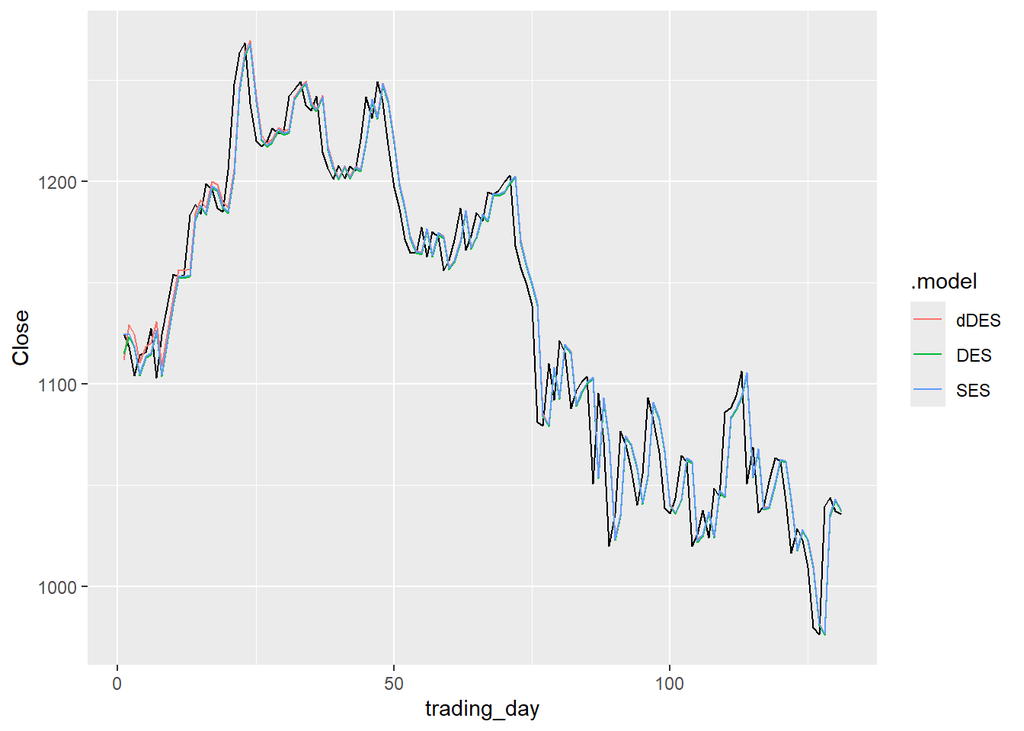

```r
#plot observed v. fitted
fit2%>%augment()%>%
  ggplot()+
  geom_line(aes(trading_day,Close))+
  geom_line(aes(trading_day,.fitted, col=.model))
```

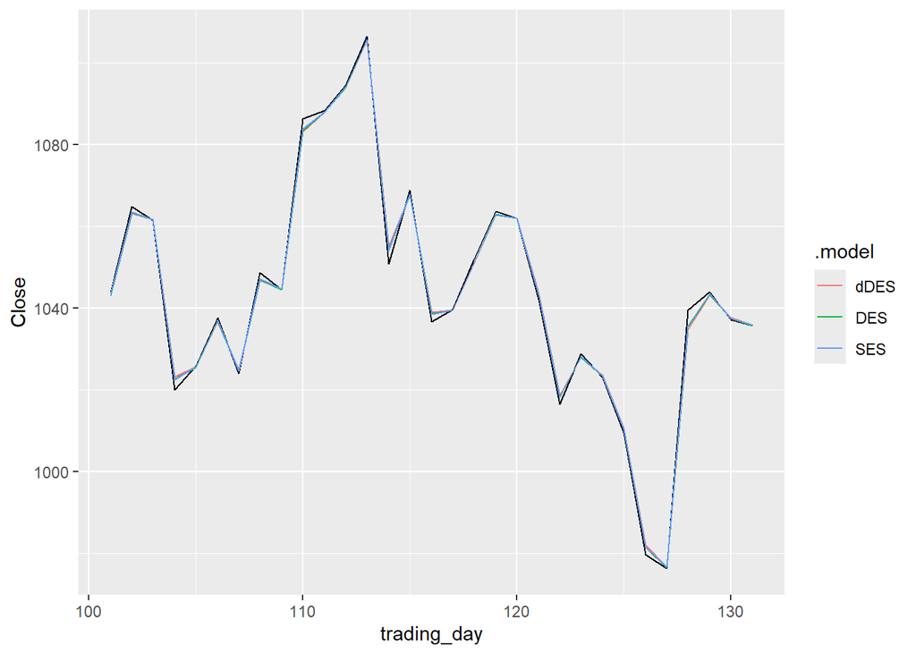

```r
#plot observation v. level : non penso abbia senso perche non consideri lo slope stupida
fit2%>%
  components()%>%
  filter(trading_day>100)%>%
  ggplot()+
  geom_line(aes(trading_day,Close))+
  geom_line(aes(trading_day,level, col=.model))
```

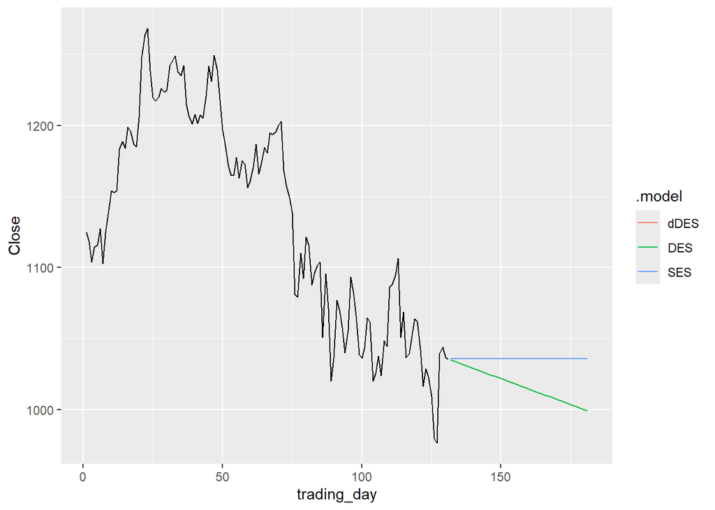

```r
#forecast and plot: SES (same as before, straight line), DES (linear function of h), dDES
fit2%>%
  forecast(h=50)%>%
  autoplot(goog_sub, level=NULL)
```

```r
#i guess i could try do this with aud prod knowing it won't work
```

#### Damped Exponential Smoothing with Trend Component (Damped Double Exp Sm)

The forecasts generated by Holt’s linear method display a constant trend (increasing or decreasing) indefinitely into the future.

This assumption is very strong.

It is introduced a parameter $\phi$ that “dampens” the trend to a flat line some time in the future.

- If $\phi =1$, the model is a DES model (linear forecasting)
- If $0<\phi<1$, the model dampens the trend, so that it approaches a constant some time in the future;
- *Short-time* forecasts are *trended* while *Long-Run* are *constant*

**The component form of Damped Exponential Smoothing**

*Forecasting Equation*: $\hat{y}_{t+h|t}= l_t + (\phi + \phi^1+ \phi^2+...\phi^h)\cdot b_t$

*Level Equation*: $l_t =\alpha y_t + (1-\alpha)(l_{t-1}+\phi b_{t-1})$

*Trend Equation*: (b_t= $\beta^*$(l_t - l_{t-1})+(1-$\beta^*$)b_{t-1})

#### Exponential Smoothing with Seasonal Component: Triple Exp Sm / Holt-Winter’s model

- comprises the forecast equation and three smoothing equations — one for the level $l_t$, one for the trend $b_t$, and one for the seasonal component $s_t$
- smoothing parameters $\alpha, \beta, \gamma$
- $m$ is the frequency of the seasonality (monthly data $m=12$, quarterly data $m=4$)
- two versions depending on the nature of the seasonal component. *Additive* when seasonal component is constant in magnitude. *Multiplicative* when seasonal component increases in magnitude with the level of the series.

##### Exp Sm with Additive Seasonal Component

**The component form of the Additive Method**

*Forecasting Equation*: $\hat{y}_{t+h|t}= l_t + h \cdot b_t + s_{t+h-m(k+1)}$

*Level Equation*: $l_t =\alpha (y_t - s_{t-m}) + (1-\alpha)(l_{t-1}+b_{t-1})$

*Trend Equation*: $b_t= \beta^*(l_t - l_{t-1})+(1-\beta^*)b_{t-1}$

*Seasonal Equation*: $s_t= \gamma (y_t - l_{t-1} - b_{t-1})+ (1-\gamma)s_{t-m}$

where:

- $k$ is the integer part of $(h-1)/m$
- Level equation shows a weighted average between the seasonally adjusted observation at time $t$ and the non-seasonal forecast for time $t$ ($\hat{y}_{t|t-1}= l_{t-1}+ b_{t-1}$)
- Trend equation shows a weighted average between the actual trend and the estimated trend at time $t-1$ for time $t$
- Seasonal equation is a weighted average between the current seasonal index and the seasonal index estimated for the same season last year ($m$ periods ago)
- $\gamma = \gamma^*(1-\alpha)$

```r
#fit the model: triple exp sm additive
fit3<-aus_production%>%
  filter(year(Quarter)>2000)%>%
  select(Quarter, Beer)%>%
  model(TES=ETS(Beer ~ trend('A')+ season('A')+error('A')))

fit3%>%tidy()
```

```
## # A tibble: 9 × 3
##   .model term    estimate
##   <chr>  <chr>      <dbl>
## 1 TES    alpha   0.000512
## 2 TES    beta    0.000100
## 3 TES    gamma   0.000100
## 4 TES    l[0]  438.
## 5 TES    b[0]   -0.482
## 6 TES    s[0]   56.2
## 7 TES    s[-1] -18.7
## 8 TES    s[-2] -36.0
## 9 TES    s[-3]  -1.55
```

```r
fit3%>%components()
```

```
## # A dable: 42 x 7 [1Q]
## # Key:     .model [1]
## # :        Beer = lag(level, 1) + lag(slope, 1) + lag(season, 4) + remainder
##    .model Quarter  Beer level  slope season remainder
##    <chr>    <qtr> <dbl> <dbl>  <dbl>  <dbl>     <dbl>
##  1 TES    2000 Q1    NA   NA  NA      -1.55    NA
##  2 TES    2000 Q2    NA   NA  NA     -36.0     NA
##  3 TES    2000 Q3    NA   NA  NA     -18.7     NA
##  4 TES    2000 Q4    NA  438. -0.482  56.2     NA
##  5 TES    2001 Q1   451  438. -0.481  -1.55    14.8
##  6 TES    2001 Q2   380  437. -0.483 -36.0    -21.3
##  7 TES    2001 Q3   416  437. -0.483 -18.7     -2.09
##  8 TES    2001 Q4   492  436. -0.483  56.2     -0.519
##  9 TES    2002 Q1   428  436. -0.484  -1.55    -6.25
## 10 TES    2002 Q2   408  435. -0.483 -36.0      8.69
## # ℹ 32 more rows
```

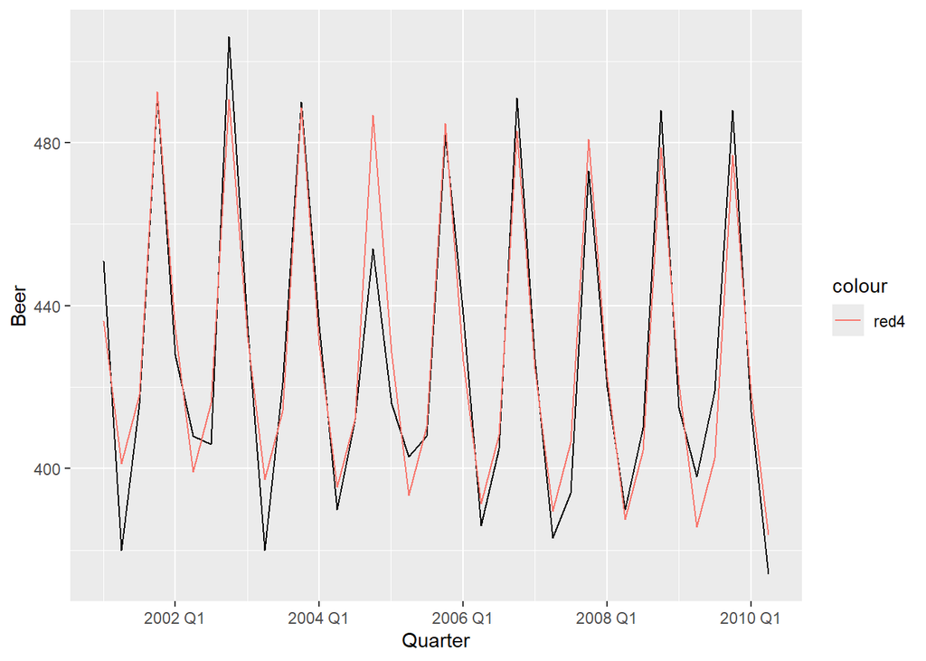

```r
#plot observations v. fitted
fit3%>%
  augment()%>%
  ggplot()+
  geom_line(aes(Quarter, Beer))+
  geom_line(aes(Quarter, .fitted, col='red4'))
```

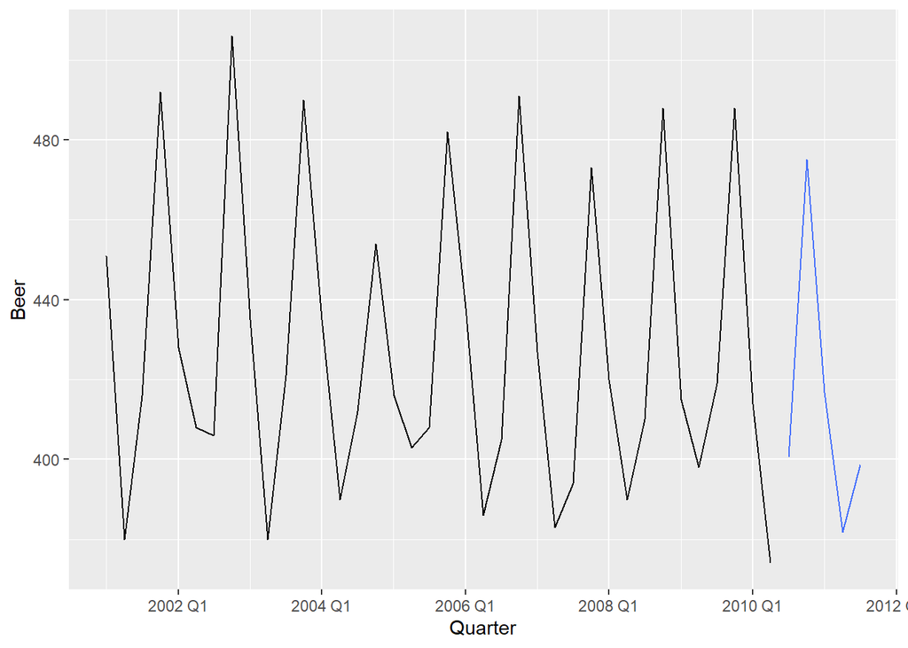

```r
#forecast and plot original ts with forecast
fit3%>%
  forecast(h=5)%>%
  autoplot(aus_production%>%filter(year(Quarter)>2000), level= NULL)
```

##### Exp Sm with Multiplicative Seasonal Component

**The component form of the Multiplicative Method**

*Forecasting Equation*: $\hat{y}_{t+h|t}= (l_t + h \cdot b_t)\cdot s_{t+h-m(k+1)}$

*Level Equation*: $l_t =\alpha \frac{y_t}{s_{t-m}} + (1-\alpha)(l_{t-1}+b_{t-1})$

*Trend Equation*: $b_t= \beta^*(l_t - l_{t-1})+(1-\beta^*)b_{t-1}$

*Seasonal Equation*: $s_t= \gamma \frac{y_t}{l_{t-1} - b_{t-1}}+ (1-\gamma)s_{t-m}$

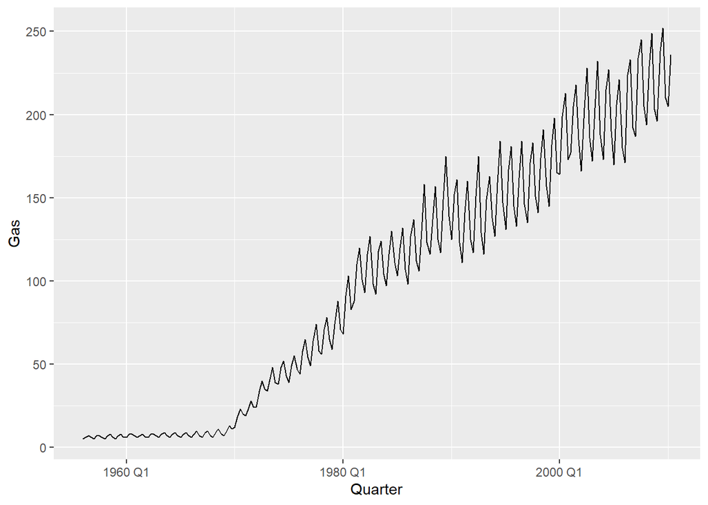

```r
#ts with trend, seasonality increasing in magnitude
aus_production%>%
  select(Quarter, Gas)%>%
  ggplot()+
  geom_line(aes(Quarter,Gas))
```

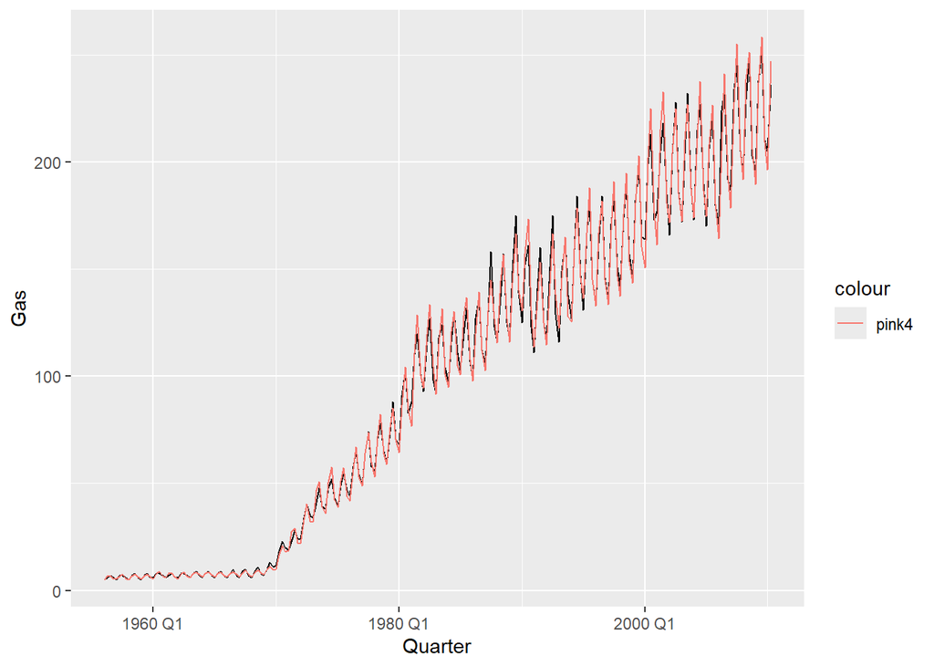

```r
#fit the multiplicative model
fit4<-aus_production%>%
  select(Quarter, Gas)%>%
  model(TESm=ETS(Gas~trend('A')+season('M')+error('M')))

#plot the observations v. .fitted
fit4%>%
  augment()%>%
  ggplot()+
  geom_line(aes(Quarter, Gas))+
  geom_line(aes(Quarter, .fitted, colour = 'pink4'))
```

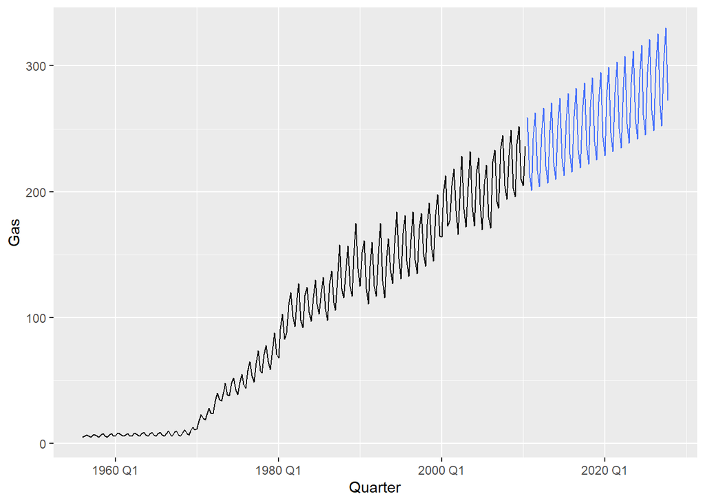

```r
#forecast
fit4%>%
  forecast(h=70)%>%
  autoplot(aus_production%>%select(Quarter, Gas), level=NULL)
```

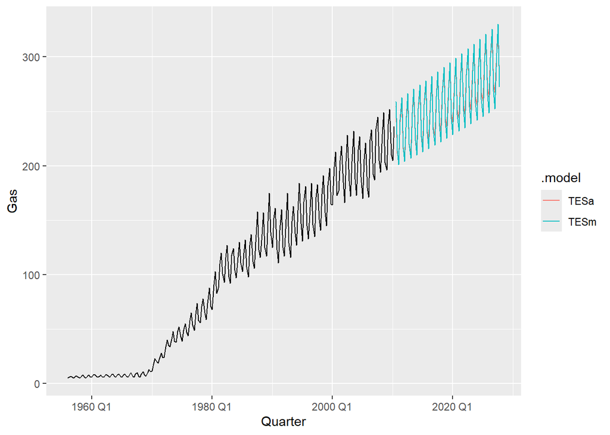

```r
#fit multiplicative v additive for a meant to be multiplicative
fit5<-aus_production%>%
  select(Quarter, Gas)%>%
  model(TESm=ETS(Gas~trend('A')+season('M')+error('M')),
        TESa=ETS(Gas~trend('A')+season('A')+error('A')))

#forecast: additive doesn't predict any increase in magnitude for seasonal component
fit5%>%
  forecast(h=70)%>%
  autoplot(aus_production%>%select(Quarter, Gas), level=NULL)
```

#### Damped Exponential Smoothing with Seasonal Component (Damped Triple Exp Sm)

##### Damped Triple Exp Sm Multiplicative

**The component form of the Multiplicative Method**

*Forecasting Equation*: $\hat{y}_{t+h|t}= [l_t + (\phi+\phi^1+\phi^2...\phi^h) \cdot b_t]\cdot s_{t+h-m(k+1)}$

*Level Equation*: $l_t =\alpha \frac{y_t}{s_{t-m}} + (1-\alpha)(l_{t-1}+\phi b_{t-1})$

*Trend Equation*: $b_t= \beta^*(l_t - l_{t-1})+(1-\beta^*)\phi b_{t-1}$

*Seasonal Equation*: $s_t= \gamma \frac{y_t}{l_{t-1} - \phi b_{t-1}}+ (1-\gamma)s_{t-m}$

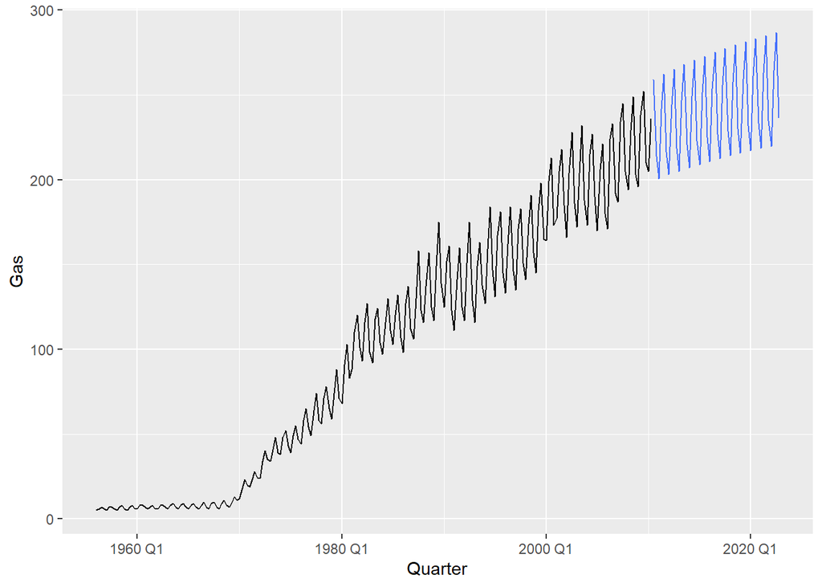

```r
#fit the damped multiplicative model of Triple Exponential Smoothing
fit6<-aus_production%>%
  select(Quarter, Gas)%>%
  model(dTESm=ETS(Gas~trend('Ad')+season('M')+error('M')))

#plot original ts + forecasted
fit6%>%
  forecast(h=50)%>%
  autoplot(aus_production%>%select(Quarter, Gas), level=NULL)
```

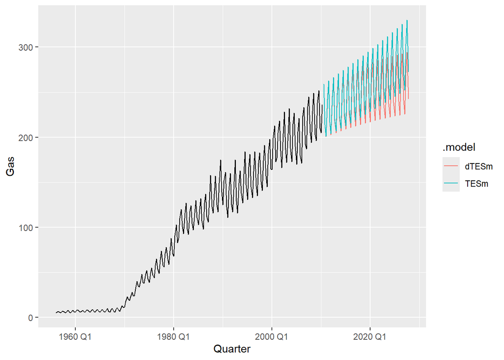

```r
#comparison multiplicative v. damped multiplicative
fit7<-aus_production%>%
  select(Quarter, Gas)%>%
  model(dTESm=ETS(Gas~trend('Ad')+season('M')+error('M')),
        TESm=ETS(Gas~trend('A')+season('M')+error('M')))

fit7%>%
  forecast(h=70)%>%
  autoplot(aus_production%>%select(Quarter, Gas), level=NULL)
```

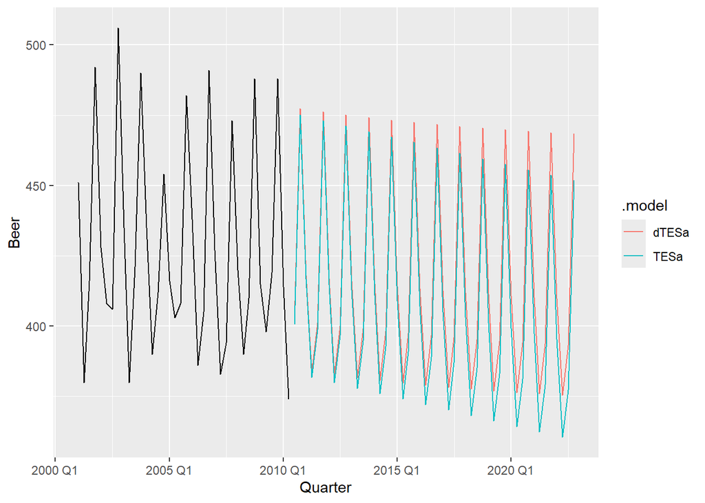

```r
#damped additive model of Triple Exponential Smoothing
lol<-aus_production%>%
  filter(year(Quarter)>2000)%>%
  select(Quarter, Beer)%>%
  model(TESa=ETS(Beer~trend('A')+season('A')+error('A')),
        dTESa=ETS(Beer~trend('Ad')+season('A')+error('A')))

lol%>%
  forecast(h=50)%>%
  autoplot(aus_production%>%filter(year(Quarter)>2000)%>%select(Quarter, Beer), level=NULL)
```

## Exercises

- Reconstruct the calculations needed to derive the components in the multiplicative decomposition that was obtained for the Australian Gas Production
- Compute a 5-MA and 9-MA for the oil prices in the `prices` dataset and overlay them to the original data ensuring that suitable labels are used to identify the different fits

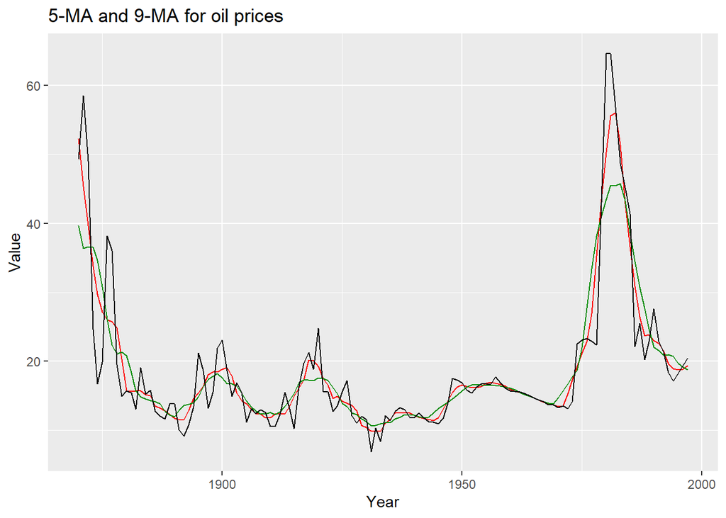

```r
library(slider)

MAs<-prices%>%
  filter(year>1869)%>%
  select(year, oil)%>%
  mutate(MA5=slide_dbl(oil,.f=mean, .before=2,.after=2,.step=1, complete=TRUE),
         MA9=slide_dbl(oil,.f=mean, .before=4,.after=4,.step=1, complete=TRUE))

#non si legge la leggenda
MAs%>%ggplot()+
  geom_line(aes(year,MA5),col='red')+
  geom_line(aes(year,MA9), col='green4')+
  geom_line(aes(year,oil))+
  labs(title = '5-MA and 9-MA for oil prices',
       x='Year',
       y='Value')
```

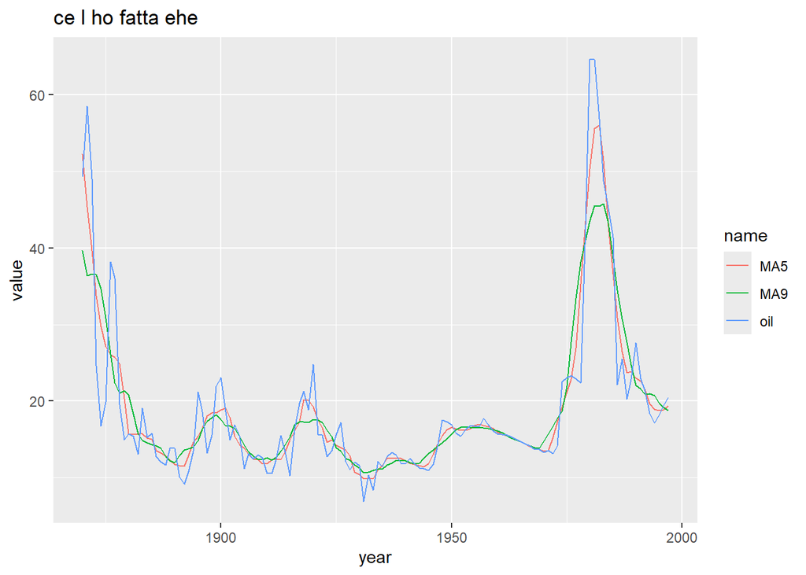

```r
#merge
MAs<-MAs%>%
  pivot_longer(cols = c(oil,MA5,MA9))

#plot
MAs%>%ggplot()+
  geom_line(aes(year, value, col=name))+
  labs(title = 'ce l ho fatta ehe')
```

- Decompose the US Retail sector time series

```r
#us_retail <-
  #us_employment %>%
 #   filter(Title == "Retail Trade", year(Month) >= 1980)

#us_retail%>%ggplot()+
  #geom_line(aes(Month,Employed))

#dec<-us_retail%>%
 # select(Month, Employed)%>%
  #classical_decomposition(Employed, type='a')
''
```

```
## [1] ""
```

Use an additive classical decomposition. Plot the components and comment on possible issues in the resulting decomposition.

- Derive the numerical values for the multiplicative triple exponential smoothing (“Triple_Mult”) of the Australian beer production model seen above
- Focus on the Tobacco production in Australia: the values are contained in the `aus_production` dataset: discuss whether a single, double or triple exponential smoothing would be more appropriate to smooth this time series. Compare the 20-step ahead forecast obtained when using a triple exponential smoothing with a damped and non-damped trend.
- Focus on the `global_economy` dataset: pick a country (say France) and produce a simple exponential smoothing forecast for the country GDP. Discuss whether a double exponential smoothing or triple exponential smoothing would be suitable to use for smoothing the time series.